# Unit 7 - Regression Review

James Flynn

September 23, 2026

## Linear Regression

- Linear regression (OLS) is the workhorse behind the methods we use for causal inference
- It can be used for
  - DiD
  - IV (at least partially)
  - RDD
  - We can often get causal estimates without these
- Let’s refresh how it works

## Regression Mechanics

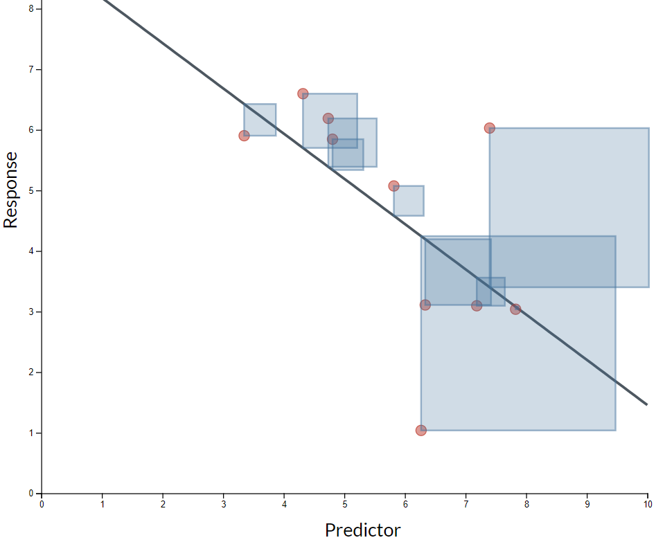

## Remember SST, SSR and SSE?

Total Sum of Squares (SST):

$SST = \sum_{i=1}^n (y_i-\bar{y})^2$

Explained Sum of Squares (SSE):

$SSE = \sum_{i=1}^n (\hat{y_i}-\bar{y})^2$

Sum of Squared Residuals (SSR):

$SSR = \sum_{i=1}^n (\hat{u}^2)$

## SST, SSR, SSE (cont’d)

$SST = SSR + SSE$

-Who remembers how to calculate $R^2$?

## $R^2$ formula

- $R^2$ is the ratio of total variation in y that is explained by our OLS line:

$R^2 = \frac{SSE}{SST} = 1-\frac{SSR}{SST}$

$R^2 = 0 \implies$ no relationship

$R^2 = 1 \implies$ perfect linear relationship

## Don’t fixate too much on $R^2$

- It can be a useful measure
  - However, it tells us *nothing* about causality
- $R^2$ more valuable for ML and prediction
  - Even then, it can be overutilized
  - Can also tell us how good our controls are
- That said, we are going to fixate on $R^2$ for a minute

## Fun with $R^2$

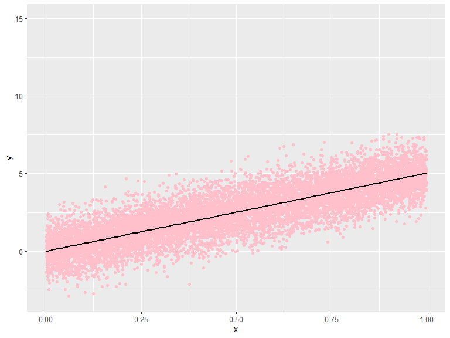

```
## [1] 0.6799835
```

## Higher or lower R^2, or same?

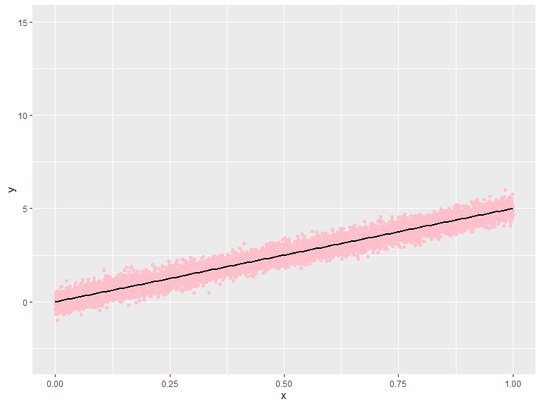

## Who said higher?

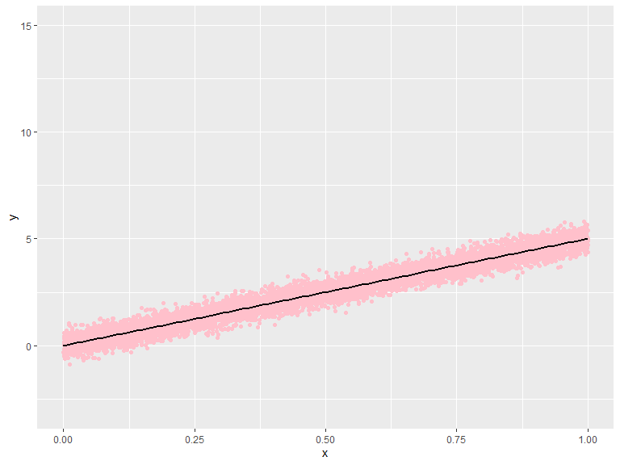

```
## [1] 0.9584234
```

## How about now?

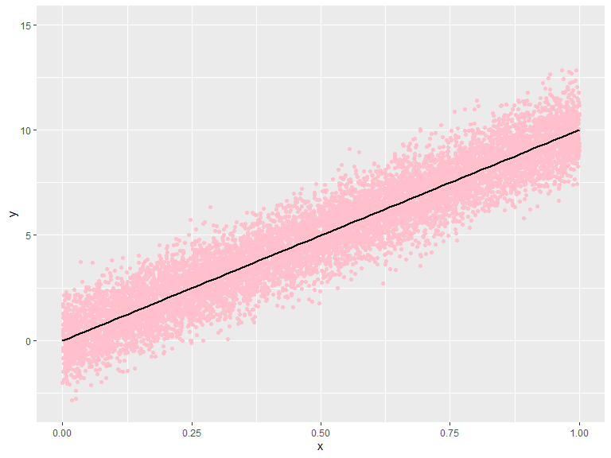

## What happened here?

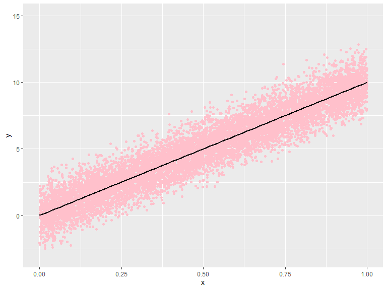

```
## [1] 0.8909986
```

## What happens when you include a dummy variable?

- How does that change our regression?
- When would we want to do it

## What it looks like without

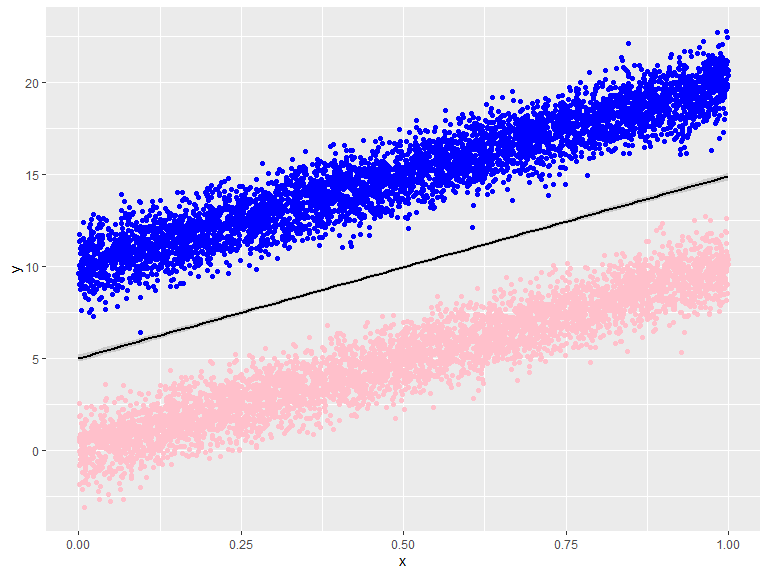

```
## [1] 0.2401575
```

## And now with…

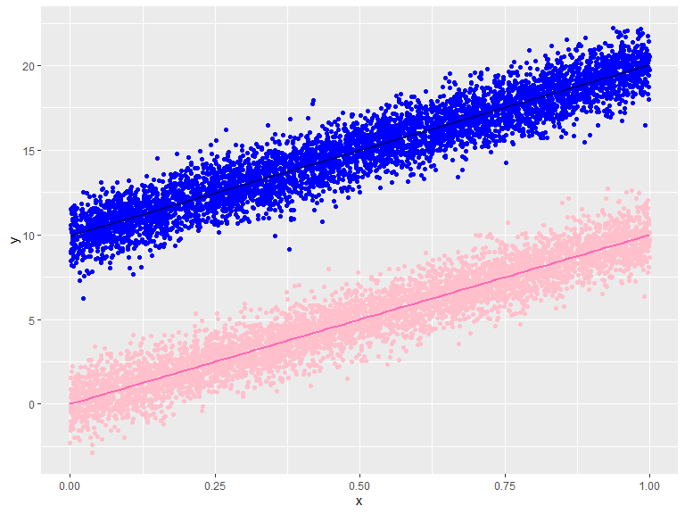

```
## [1] 0.9710421
```

## Let’s look at the regression

```r
summary(lm(y~x+z))
```

```
##
## Call:
## lm(formula = y ~ x + z)
##
## Residuals:
##     Min      1Q  Median      3Q     Max
## -4.6343 -0.6754  0.0080  0.6657  3.7446
##
## Coefficients:
##             Estimate Std. Error t value Pr(>|t|)
## (Intercept) -0.02289    0.02248  -1.018    0.309
## x           10.03936    0.03470 289.309   <2e-16 ***
## z            9.98857    0.02000 499.409   <2e-16 ***
## ---
## Signif. codes:  0 '***' 0.001 '**' 0.01 '*' 0.05 '.' 0.1 ' ' 1
##
## Residual standard error: 0.9999 on 9997 degrees of freedom
## Multiple R-squared:  0.971,  Adjusted R-squared:  0.971
## F-statistic: 1.676e+05 on 2 and 9997 DF,  p-value: < 2.2e-16
```

## Regression Mechanics (cont’d)

- We’ll start with some definitions
- *Expected value* - the expected value of a random variable is the sum of all possible values a variable can take multiplied by the probability of drawing that value
  - Also called the population mean or expectation
- Suppose x can take values $x_1, x_2,...,x_k$, each with probability $f(x_1),f(x_2),...,f(x_k)$

## Expected Value Formula

$$E[X] = \sum_{n=1}^k
x_nf(x_n)$$

- Example - Dice Roll 1(1/6)+2(1/6)+3(1/6)+4(1/6)+5(1/6)+6(1/6) = 21/6 = 3.5

## Example 2 - Mega Millions

- On the day I wrote this slide, the Mega Millions jackpot was $33 million
- Odds of winning: 1 in 302.6 million
- Ticket costs $2
  - 0.00000033% chance of winning $32,999,998
  - 99.99999967% chance of losing $2
- Expected value = .11 - 2 = -$1.89
- Another example - expected goals in hockey/soccer

## E[X] is a weighted mean

- If observations have equal weight (probability), E[X] is just the mean
- When would observations have unequal weight?
  - Dice roll with two die
  - Representative surveys

## Introducing Variance using E[]

- The variance of a random variable X is

$$V(X) = \sigma^2 =
E[(X-E[X])^2]$$

- The inside function measures raw deviation from the mean
- The outside E[] averages the inside function

## Properties of the Variance

- $$V(\alpha X) = \alpha^2V(X)$$
- $$V(X+\beta) = V(X)$$
- $$V(constant) = 0$$

## Variance and Covariance

- Variance measures the *spread* of one variable
- Covariance measure how much two variables move *together*
- Covariance formula:

$$Cov(X,Y) = E[XY] - E[X]E[Y]$$

## Class Exercise

Show that:

$$Cov(X,Y) = E[XY] - E[X]E[Y]$$

in R using Goals and Assists from the NHL dataset

```r
nhl <- haven::read_dta("NHL Master Dataset.dta") %>%
    filter(year>2012)
```

## Solution

```r
nhl <- nhl %>% mutate(goals_assists = Goals * Assists)

E_goals_assists <- mean(nhl$goals_assists)
E_goals <- mean(nhl$Goals)
E_assists <- mean(nhl$Assists)

cov_goals_assists <- E_goals_assists - E_goals*E_assists
cov_goals_assists
```

```
## [1] 78.89663
```

```r
cov(nhl$Goals,nhl$Assists)
```

```
## [1] 78.91159
```

## Unpacking Covariance

- Cov(X,Y) > 0 implies X and Y move together
- Cov(X,Y) < 0 implies X and Y move in the opposite direction
- Cov(X,Y) = 0 does not mean there is no relationship
  - Could be nonlinear relationship

## Let’s go through some common regression hacks

Let’s use the NHL data to illustrate some common moves

```r
nhl <- nhl %>%
    mutate(Log_sal=log(Salary),log_points=log(Points)) %>%
    filter(is.na(Salary)==FALSE)
```

Why take logs?

## Log transformation

- When does it make sense to take logs?
- Benefits
  - Linearizes data which takes extreme values
  - Reduces skew
  - Mitigates the effect of outliers
  - Can improve interpretability
- Concerns
  - Can’t take log of 0 (why??)
  - Not appropriate for linear data
  - Can lead to overfitting

## What to do with log(0) issue

- Most common: log(x+1)
  - Get ready to fight
- Take square root
  - Won’t help with negatives
- Inverse hyperbolic sine transformation
  - Similar properties to log
  - sinh(x)

  *Don’t just ignore it*

## Interpreting logs

- level-level: change in x $\implies$ change in y
- log-level: change in x $\implies$ % change in y
- level-log: % change in x $\implies$ change in y
- log-log: % change in x $\implies$ % change in y
  - What do we call this last one?

## Polynomials of X variables

- Often we’ll have a nonlinear relationship with one of our variables
- Let’s look at how points per season depends on age

```r
nhl <- nhl %>% mutate(age2 = Age^2)
```

## Let’s take a look

```r
m1 <- lm(Points ~ Age, data = nhl)
m2 <- lm(Points ~ Age + age2, data = nhl)
msummary(list(m1,m2), stars = TRUE, gof_omit = 'AIC|BIC|Lik|Adj.|F|R2|RMSE')
```

|  | (1) | (2) |
| --- | --- | --- |
| (Intercept) | 7.362*** | -11.213 |
|  | (1.632) | (8.525) |
| Age | 0.457*** | 1.829** |
|  | (0.061) | (0.621) |
| age2 |  | -0.025* |
|  |  | (0.011) |
| Num.Obs. | 5165 | 5165 |

+ p < 0.1, * p < 0.05, ** p < 0.01, *** p < 0.001

## How to interpret polynomials

- Need to take derivative wrt age

$$Points = \beta_0 + \beta_1 Age + \beta_2
Age^2$$

$$\frac{d Points}{dAge} = \beta_1 +
2\beta_2 Age$$

## Binary Variables just get a difference in means

```r
nhl <- nhl %>% mutate(defense=Position=="D")
summary(lm(Points~defense,data=nhl))
```

```
##
## Call:
## lm(formula = Points ~ defense, data = nhl)
##
## Residuals:
##     Min      1Q  Median      3Q     Max
## -22.185 -14.295  -5.185  10.815  85.815
##
## Coefficients:
##             Estimate Std. Error t value Pr(>|t|)
## (Intercept)  22.1853     0.3296   67.30   <2e-16 ***
## defenseTRUE  -7.8898     0.5604  -14.08   <2e-16 ***
## ---
## Signif. codes:  0 '***' 0.001 '**' 0.01 '*' 0.05 '.' 0.1 ' ' 1
##
## Residual standard error: 19.16 on 5163 degrees of freedom
## Multiple R-squared:  0.03697,    Adjusted R-squared:  0.03679
## F-statistic: 198.2 on 1 and 5163 DF,  p-value: < 2.2e-16
```

Defenseman score eight less points on average

## How to deal with categorical variables?

- What if I want to know difference in points for each position?

```r
summary(lm(Points~factor(Position),data=nhl))
```

```
##
## Call:
## lm(formula = Points ~ factor(Position), data = nhl)
##
## Residuals:
##     Min      1Q  Median      3Q     Max
## -24.296 -14.295  -5.295  10.704  85.028
##
## Coefficients:
##                    Estimate Std. Error t value Pr(>|t|)
## (Intercept)         24.2956     0.4682  51.889  < 2e-16 ***
## factor(Position)D  -10.0001     0.6504 -15.376  < 2e-16 ***
## factor(Position)LW  -4.9673     0.8001  -6.208 5.78e-10 ***
## factor(Position)RW  -3.3238     0.8041  -4.133 3.63e-05 ***
## ---
## Signif. codes:  0 '***' 0.001 '**' 0.01 '*' 0.05 '.' 0.1 ' ' 1
##
## Residual standard error: 19.08 on 5161 degrees of freedom
## Multiple R-squared:  0.04496,    Adjusted R-squared:  0.0444
## F-statistic: 80.98 on 3 and 5161 DF,  p-value: < 2.2e-16
```

## This should hold up when we just look at means

```r
nhl %>% group_by(Position) %>% summarise(mean_points=mean(Points))
```

```
## # A tibble: 4 × 2
##   Position mean_points
##   <chr>          <dbl>
## 1 C               24.3
## 2 D               14.3
## 3 LW              19.3
## 4 RW              21.0
```

## Also known as…

- When we include a dummy for each value of a variable, this is also called a ‘fixed effect’
- Most commonly with time and geography
  - Year FE - controls for time-varying aspect of all groups
  - Unit FE (county?) - Controls for time-invariant characteristics of each area
- Put them together for TWFE (what could go wrong?)

## What about interaction terms?

```r
m1 <- lm(Log_sal ~ Goals, data = nhl)
m2 <- lm(Log_sal ~ Assists, data = nhl)
m3 <- lm(Log_sal ~ Goals + Assists + Goals*Assists, data = nhl)
msummary(list(m1,m2,m3), stars = TRUE, gof_omit = 'AIC|BIC|Lik|Adj.|F|R2|RMSE',coef_omit = 'Intercept')
```

|  | (1) | (2) | (3) |
| --- | --- | --- | --- |
| Goals | 0.052*** |  | 0.031*** |
|  | (0.001) |  | (0.002) |
| Assists |  | 0.042*** | 0.046*** |
|  |  | (0.001) | (0.001) |
| Goals × Assists |  |  | -0.001*** |
|  |  |  | (0.000) |
| Num.Obs. | 5165 | 5165 | 5165 |

+ p < 0.1, * p < 0.05, ** p < 0.01, *** p < 0.001

## Let’s pause and think about ‘controlling’ more

- What does it mean to ‘control’ for X?
  - We will use the Frisch, Waugh, Lovell (FWL) theorem

## FWL Setup

- Beginning with our education-wages problem
- Underlying ability is endogenous
- What if we add SAT score to our regression?

$$wages = \beta_0 + \beta_1
ed$$

becomes

$$wages = \beta_0 + \beta_1 ed + \beta_2
SAT$$
- $\beta_1$ is interpreted as ‘the increase in wages from an additional year of schooling, holding SAT score constant’

## What is held constant?

Our model is now:

$$E[wage|ed,SAT] = \beta_0 + \beta_1 ed +
\beta_2 SAT$$
so

$$\frac{\delta E[wage|ed,SAT]}{\delta ed}
= \beta_1$$

- Note that $\beta_1$ is not a function of SAT

## Instead of running the regression

- Run two regressions $X_2$ on the RHS
- One with $X_1$ as the DV, and one with $Y$ as the DV.
- Calculate residuals (denote as $Y^*$ and $X_1^*$)
- Now estimate:

$$Y^* = X_1^*\gamma + u^*$$
using normal OLS. Now:

$\hat{\gamma} = \hat{\beta_1}$ and $\hat{u^*}=\hat{u}$

## Let me prove it to you

```r
SAT <- rnorm(10000)
ed <- rnorm(10000) + .2*SAT
wages <- runif(10000,10,100) + 2*ed + SAT

summary(lm(wages~SAT + ed))
```

```
##
## Call:
## lm(formula = wages ~ SAT + ed)
##
## Residuals:
##     Min      1Q  Median      3Q     Max
## -45.349 -22.266  -0.323  22.415  45.292
##
## Coefficients:
##             Estimate Std. Error t value Pr(>|t|)
## (Intercept)  54.9302     0.2584 212.596  < 2e-16 ***
## SAT           1.0807     0.2658   4.066 4.83e-05 ***
## ed            1.7769     0.2609   6.810 1.03e-11 ***
## ---
## Signif. codes:  0 '***' 0.001 '**' 0.01 '*' 0.05 '.' 0.1 ' ' 1
##
## Residual standard error: 25.84 on 9997 degrees of freedom
## Multiple R-squared:  0.007491,   Adjusted R-squared:  0.007293
## F-statistic: 37.73 on 2 and 9997 DF,  p-value: < 2.2e-16
```

## First step

```r
res_1 <- lm(ed~SAT)$residuals
res_2 <- lm(wages~SAT)$residuals
FWL_reg <- lm(res_2 ~ res_1)
summary(FWL_reg)
```

```
##
## Call:
## lm(formula = res_2 ~ res_1)
##
## Residuals:
##     Min      1Q  Median      3Q     Max
## -45.349 -22.266  -0.323  22.415  45.292
##
## Coefficients:
##               Estimate Std. Error t value Pr(>|t|)
## (Intercept) -1.774e-16  2.583e-01   0.000        1
## res_1        1.777e+00  2.609e-01   6.811 1.03e-11 ***
## ---
## Signif. codes:  0 '***' 0.001 '**' 0.01 '*' 0.05 '.' 0.1 ' ' 1
##
## Residual standard error: 25.83 on 9998 degrees of freedom
## Multiple R-squared:  0.004618,   Adjusted R-squared:  0.004518
## F-statistic: 46.38 on 1 and 9998 DF,  p-value: 1.029e-11
```

## Class exercise

- Prove this to yourself using any three variables
- Can use the hockey data or any other data
  - Or you can make data up like I did

## FWL informs each of the following

- Interpret our coefficients
- Understand when/how our regression is identified
  - What if SAT absorbed all the variation in ed?
- See how controls affect the precision of $\hat{\beta_1}$

## Last note about controls

- Adding controls influences the SE of $\beta_1$
- We will do a deep dive on standard errors next week, but:

$$SE(\beta_1) = \sqrt{\frac{\sum_i
\hat{u_i^*}^2}{\sum_i(x_i^*-\bar{x^*})^2}}$$
- We can reduce SE (and our p-values) by including controls that soak up more variation in y than they do in x

## Shifting towards causal thinking

- We have two variables, X and Y
- We want to know if X affects Y
- Three key questions
  - Does anything else affect Y?
  - What is the functional form connecting X and Y
  - How to distinguish correlation from causation
- We will use our more rigorous understanding of what ‘controlling’ does

## As always, we start with a model

The linear bivariate regression model we know and love:

$$y = \beta_0 + \beta_1x + u$$

- This *assumes* a linear relationship
- $\beta_0$ and $\beta_1$ are pop. parameters
  - We **never** observe these
  - Our goal is to *estimate* them using *data* and *assumptions*

## We have our OLS slope estimate

$\hat{\beta_1} = \frac{cov(x,y)}{var(x)}$

- Can be computed whenever var(x) is not zero
  - This means we *need* variation in x
  - We can’t use a sample of all high school grads to get the returns to HS
- With $\hat{\beta_1}$, $\hat{\beta_0}$ is straightforward to compute
- Our residual, $\hat{u}$, is therefore:

$\hat{u_i} = y_i - \hat{\beta_0} - \hat{\beta_1}x_i$

## Important to note difference between $u$ and $\hat{u}$

- $u$ is unobservable
- $\hat{u}$ can always be calculated if we have $\beta$’s
- *residual* represents the variation in y that is unexplained by our model
- *error term* represents the variation in y that is *random*

## Let’s think about how to interpret regressions

- Keeping the $E[]$ notation, $\hat{\beta_1}$ tells us:

$E[y|x] = \beta_0 + \beta_1x$

- Interpretation:

$$\beta_0 = E[y|x=0]$$

$$\beta_1 =
\frac{dE[y|x]}{dx}$$

## Interpretation - Multiple Regression

$E[y|x,Z] = \beta_0 + \beta_1x + \beta_2Z$

- Where Z is a vector of k controls
- Now our interpretation of $\beta_1$ is:

$$\beta_1 =
\frac{dE[y|x,Z]}{dx}$$

- $\beta_1$ tells us the effect of x on y, after eliminating the effect of Z on *both* x and y

## Checklist for running a causal regression

- If I include these controls, is my parameter of interest *identified*
  - Is there enough variation to detect an effect?
- If so, how?
- Is the *identifying variation* plausibly as good as randomization?

## Omitted Variable Bias (OVB)

- If your variation is *not* as good as an experiment, often it is because you are missing some elements of $X_i$ (some control)
- Question: if a full regression model has a causal interpretation and we leave a variable out, what goes wrong?
  - Note: the idea of running the *wrong* regression only exists when answering a causal question. The conditional expectation interpretation is always valid.

## OVB Formula

- Suppose the true model of earnings and education was:

$$y_i = \beta_0 + \beta_1 ed_i + \beta_2
SAT_i + u_i$$

- But instead you only run:

$$y_i = b_0 + b_1 ed_i +
\epsilon_i$$

- What is $\hat{b_1}$ an estimate of?

## OVB formula (cont’d)

$$b_1 =
\frac{cov(ed,y)}{var(ed)}$$

$$\equiv \frac{cov(ed, \beta_0 + \beta_1
ed_i + \beta_2 SAT_i + u_i)}{var(ed)}$$

$$\equiv \frac{\beta_1 var(ed) + \beta_2
cov(ed, SAT)}{var(ed)}$$

$$\equiv \beta_1 +
\beta_2\frac{cov(ed,SAT)}{var(ed)}$$

## OVB formula (cont’d)

- Bias is simply $\beta_2\frac{cov(ed,SAT)}{var(ed)}$
- Note that this is $\beta_2 \delta_1$ with $\delta_1$ from

$$SAT_i = \delta_0 + \delta_1 ed_i +
residual$$

- Bias is $\beta_2 \delta_1$
  - or the effect of SAT on wage, scaled by the relationship between SAT and ed

## When is this not a problem?

- Need $\beta_2 \delta_1 = 0$
  - Either SAT does not affect wage
  - or SAT and ed uncorrelated
- If either of these is true, this is *not* an omitted variable

## If we don’t have the OVB, we can still likely *sign* the bias

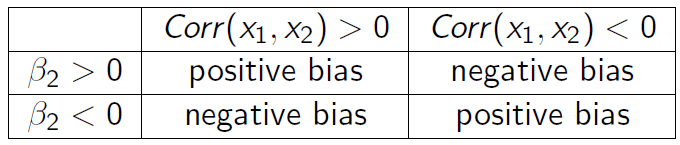

## Class exercise

- Using NHL data, let’s find out if games played (GP) is an omitted variable in the regression:

$$\text{Log_sal}_i = \beta_0 + \beta_1
Goals_i + u_i$$

- First, sign the bias using the table in the previous slide
- Then, use the formula $OVB = \beta_2 \delta_1$ to calculate it
- Finally, run the regression with and without GP
  - Was our calculation right? How can you tell?

## Answers

- First, sign the bias
  - We’d expect the coefficient on GP to be positive in explaining log_sal (+)
  - Also expect correlation between GP and Goals to be positive (+)
  - OVB should be positive

## Sign the bias

```r
#beta_2
lm1 <- lm(Log_sal~Goals+GP,data=nhl)
beta_2 <- summary(lm1)$coefficients[3,1]
beta_2
```

```
## [1] 0.009513985
```

```r
cor_goals_gp <- cor(nhl$Goals, nhl$GP)
cor_goals_gp
```

```
## [1] 0.6371922
```

```r
beta_2 >0 & cor_goals_gp >0
```

```
## [1] TRUE
```

## Calculate the bias

- We have $\beta_2$, just need $\delta_1$

```r
#delta_1
lm2 <- lm(GP~Goals,data=nhl)
delta_1 <- summary(lm2)$coefficients[2,1]
delta_1
```

```
## [1] 2.169138
```

Now multiply

```r
OVB <- beta_2 * delta_1
OVB
```

```
## [1] 0.02063715
```

## Let’s see what it does in our regression

```r
m1 <- lm(Log_sal ~ Goals, data = nhl)
m2 <- lm(Log_sal ~ Goals + GP, data = nhl)
msummary(list(m1,m2), stars = TRUE, gof_omit = 'AIC|BIC|Lik|Adj.|F')
```

|  | (1) | (2) |
| --- | --- | --- |
| (Intercept) | 13.790*** | 13.504*** |
|  | (0.013) | (0.018) |
| Goals | 0.052*** | 0.031*** |
|  | (0.001) | (0.001) |
| GP |  | 0.010*** |
|  |  | (0.000) |
| Num.Obs. | 5165 | 5165 |
| R2 | 0.262 | 0.323 |
| RMSE | 0.72 | 0.69 |

+ p < 0.1, * p < 0.05, ** p < 0.01, *** p < 0.001